# Welcome to the Course

[figure not shown]

Thank you for getting *VFX Secrets*, and welcome!

This course will teach you some techniques to create visual effects, abbreviated *vfx*, in godot.

Visual effects contribute a lot to a game’s appeal and feel. They are all sorts of animated elements that help give the player visual feedback or breathe life to the world: explosions, projectiles, waterfalls, splashes, spells, and more.

It can be hard to know how to create each of them. There is no straightforward process or method: it depends on the effect you’re trying to create.

But there are plenty of general tools and techniques you can use. As a technical or VFX artist, you slowly learn these techniques to combine them in creative ways later.

## Effects breakdown

Here is a quick look at the effects you’re going to create in the current release.

### Starfield

In this tutorial, we present GPU-based particles’ usage for environmental effects, using emission shapes, scaling curves, angular velocity, and parallax layers to create a starfield background that repeats across the screen.

### Ghost Trail

The ghost trail, also called after images, is a common effect used in action games to communicate speed. It’s the copies of the characters when you dash in Celeste or running in the 2D Castlevania games on Game Boy Advance. For this effect, we’re going to use the particles’ color ramp and Align Y property to create a trail that follows a sprite and fades out.

[figure not shown]

### Laser

Using multiple layers of particles, a line, and a raycast, you’re going to create a controllable laser beam that collides with walls and other objects.

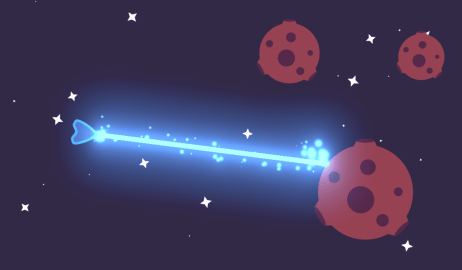

### Explosion

Learn to create an explosion with this common layered effect. Kaboom, baby!

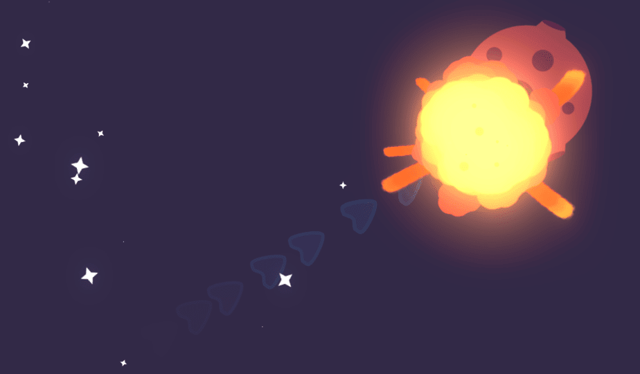

### Trail renderer

A smooth trail that’s procedurally generated behind your character or anything it’s set to track.

### Fireball

Based on the explosion, the fireball is another layered effect. It also has separate animations, so a player can charge the fireball before throwing it.

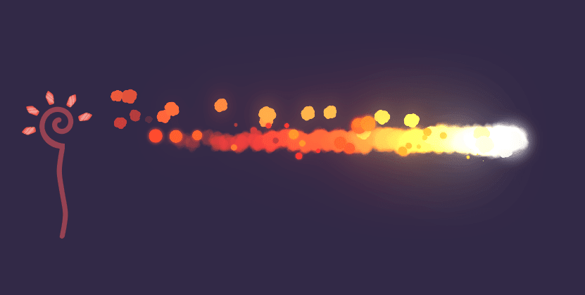

### Shockwave

The shockwave is a shader-based effect. In this tutorial, we’re taking a premade shockwave shader from our [Godot shaders repository](https://github.com/GDQuest/godot-shaders) and coding the animated distortion.

The low-level shader code itself is taught in our course dedicated to shaders: [Godot Shader Secrets](https://gdquest.mavenseed.com/courses/shader-secrets-learn-to-code-2d-and-3d-shaders-in-godot).

### Charging

Learn to animate particles moving towards the same point to create a charging effect, before unleashing a powerful attack.